# Housing_Price

model1 Residual plot normality

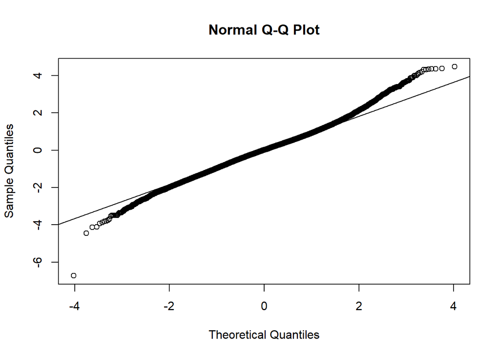

```r
qqnorm(rstandard(model1))
qqline(rstandard(model1,col="red"))
```

plot between residual and predicted

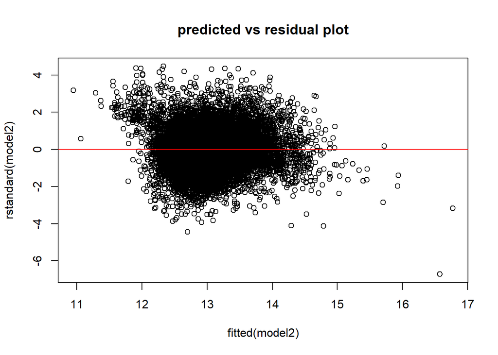

```r
plot(fitted(model2),rstandard(model2),main="predicted vs residual plot")
abline(a=0, b=0, col='red')
```

model2 Residual plot normality

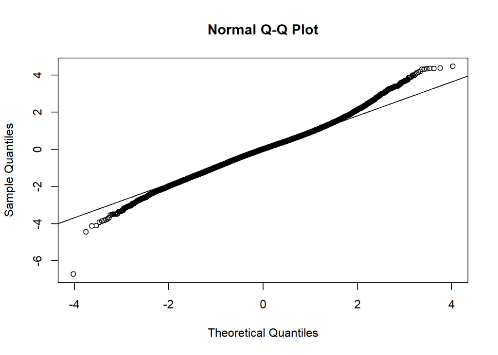

```r
qqnorm(rstandard(model2))
qqline(rstandard(model2,col="red"))
```

plot between residual and predicted

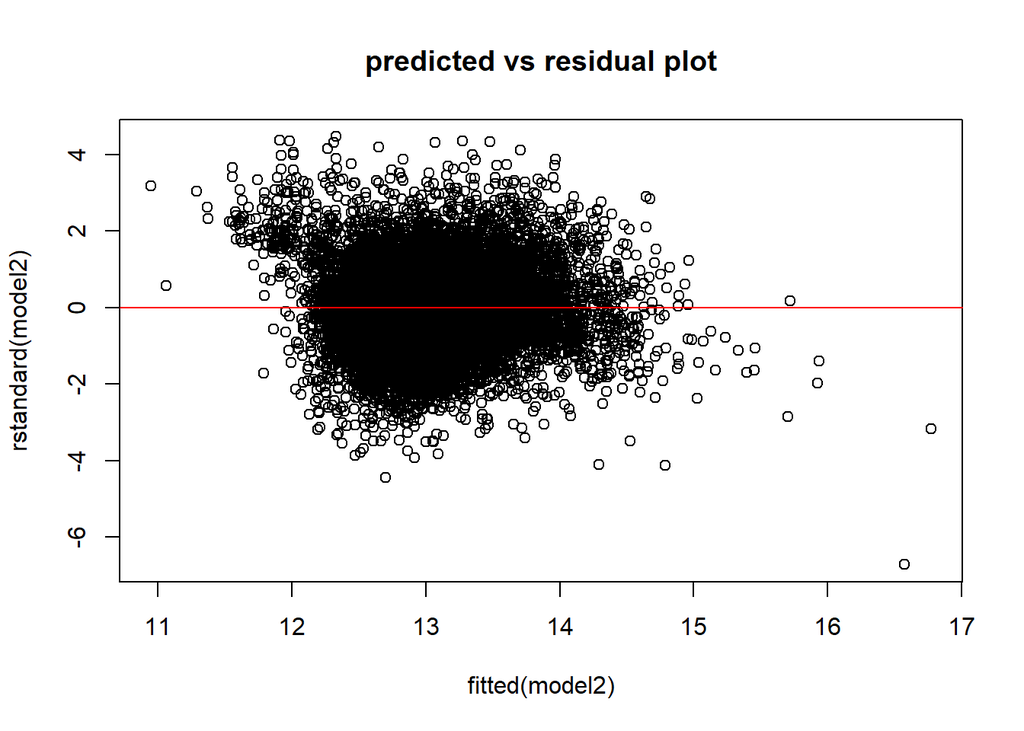

```r
plot(fitted(model2),rstandard(model2),main="predicted vs residual plot")
abline(a=0, b=0, col='red')
```

model3 Residual plot normality

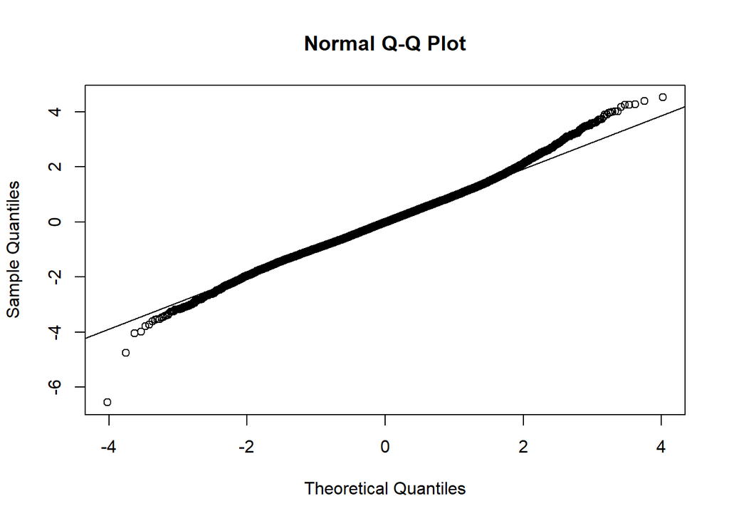

```r
qqnorm(rstandard(model3))
qqline(rstandard(model3,col="red"))
```

plot between residual and predicted

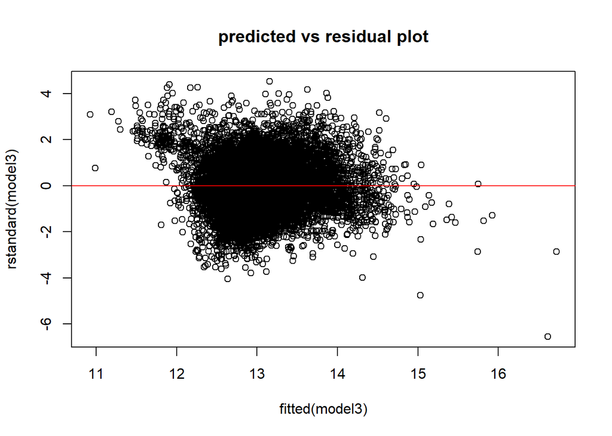

```r
plot(fitted(model3),rstandard(model3),main="predicted vs residual plot")
abline(a=0, b=0, col='red')
```

plot for residual and sqft living variable

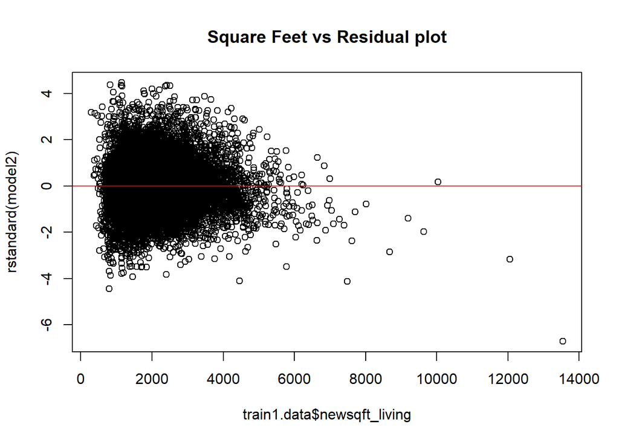

```r
plot(train1.data$newsqft_living,rstandard(model2),main="Square Feet vs Residual plot")
abline(a=0, b=0, col='red')
```

plot for residual and grade variable

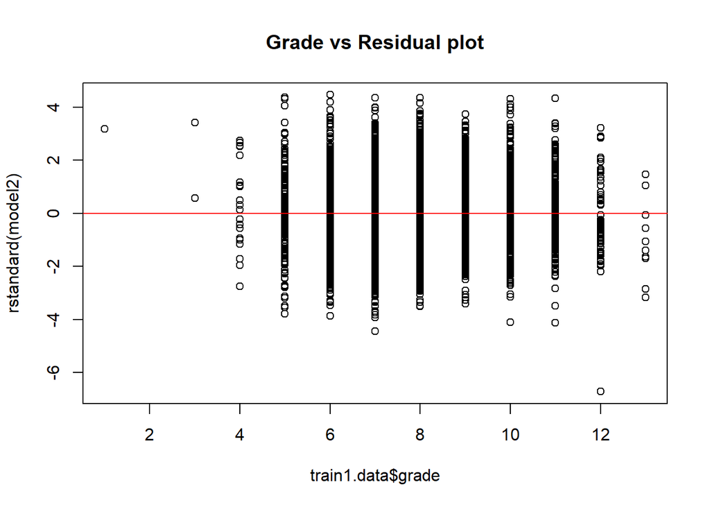

```r
plot(train1.data$grade,rstandard(model2),main="Grade vs Residual plot")
abline(a=0, b=0, col='red')
```

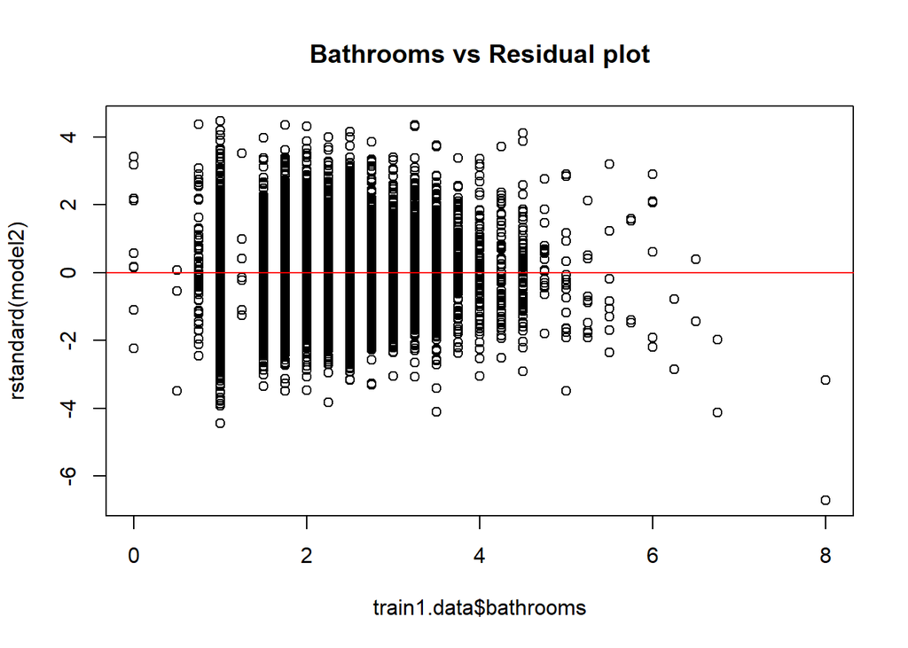

```r
plot(train1.data$bathrooms,rstandard(model2),main="Bathrooms vs Residual plot")
abline(a=0, b=0, col='red')
```

plot for residual and crime variable

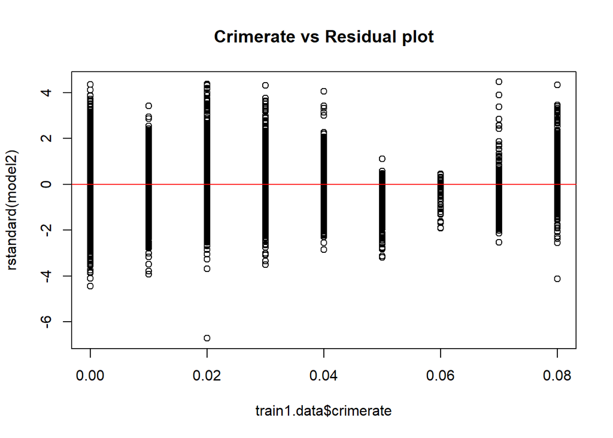

```r
plot(train1.data$crimerate,rstandard(model2),main="Crimerate vs Residual plot")
abline(a=0, b=0, col='red')
```

plot for residual and distance variable

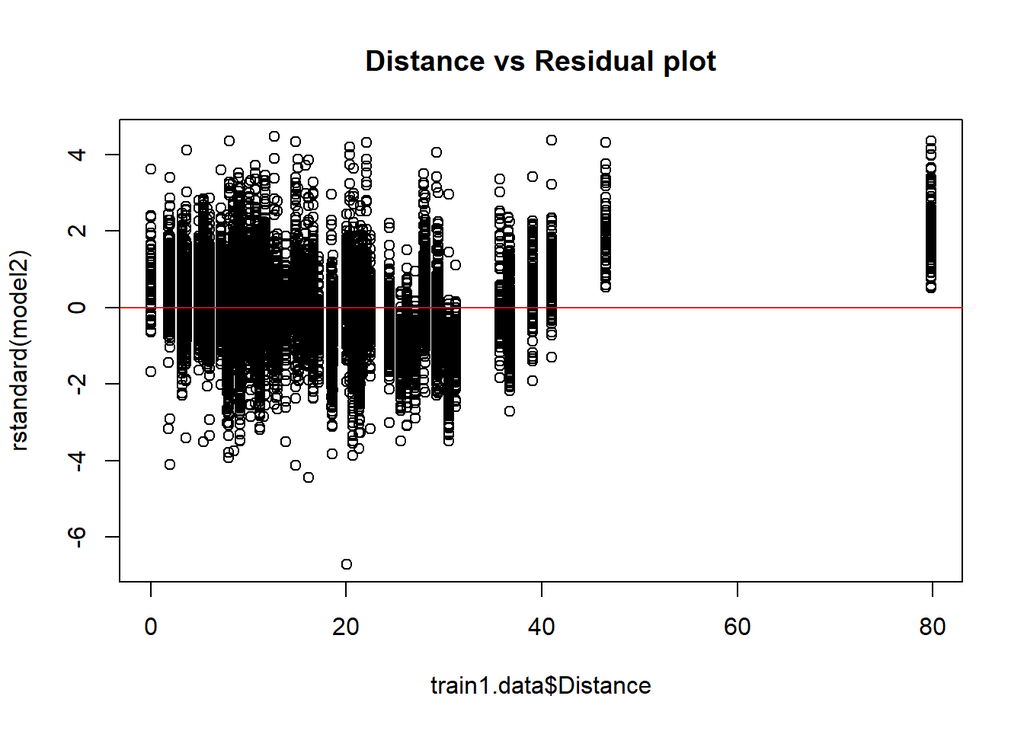

```r
plot(train1.data$Distance,rstandard(model2),main="Distance vs Residual plot")
abline(a=0, b=0, col='red')
```

plot for residual and floors variable

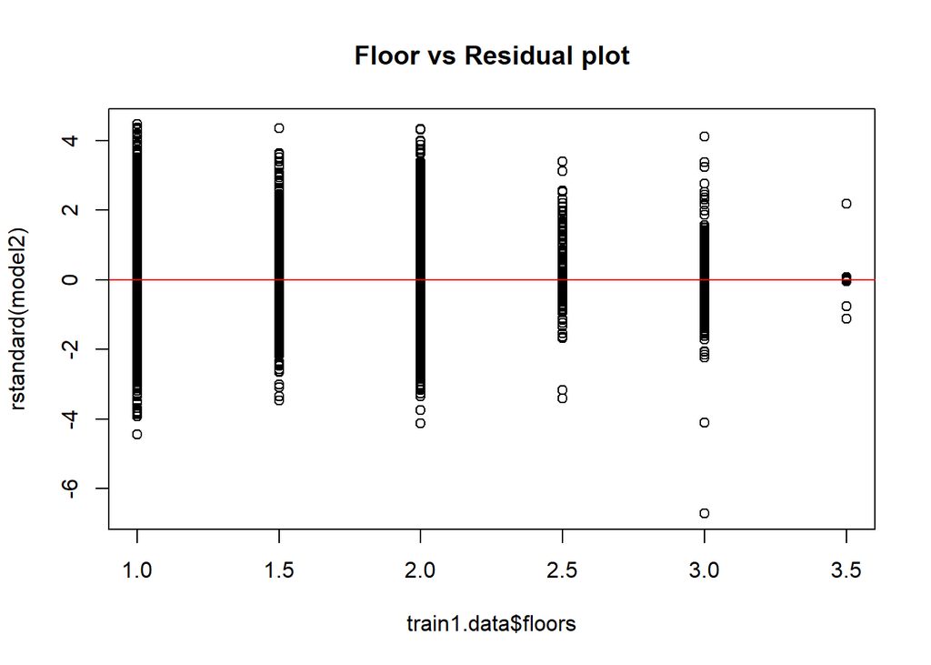

```r
plot(train1.data$floors,rstandard(model2),main="Floor vs Residual plot")
abline(a=0, b=0, col='red')
```

##Influential Points##

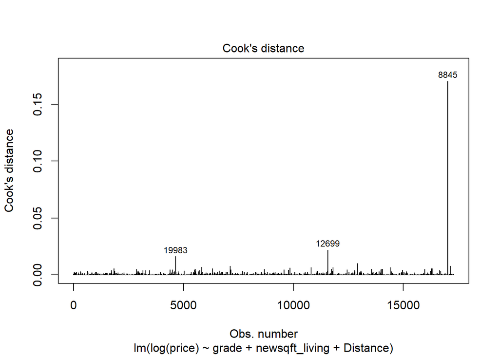

```r
cutoff <- 4/((nrow(train1.data)-length(model3$coefficients)-2))
plot(model3, which=4, cook.levels=cutoff)
```

Removing influential points

```r
fulldata2 <- fulldata[- 19983,]
fulldata2 <- fulldata[- 12699,]
fulldata2 <- fulldata[- 8845,]
data2<-fulldata2[c(2,3,13,14,15,18,19,20,21,22,31,33,34,35)]
```

Building the model again using model3 after removing influentail points

```r
selectdata2 = sample(1:nrow(data2),0.80*nrow(data2));
train2.data = data2[selectdata2,];
test2.data = data2[-selectdata2,];
```